# EDA of Prosper Loan Dataset by Subhash Bharadwaj Pemmaraju

### Structure of the dataset

Prosper is a P2P lending marketplace. The dataset is composed of 100,000+ loans listed on “Prosper”, last updated in March, 2014. It contains information on 81 variables that give details about the borrowers, lenders and loan structure.

### Variables of Interest in the dataset

The main variables of interest in the dataset are:

- Borrower Characteristics
  - Income Verifiability/Home Ownership
  - Income Range
  - Borrower State
  - Credit Score
  - Debt to Income Ratio
- Loan Characteristics
  - Credit Rating
  - Term of the loan
  - Borrower Rate
  - Loan Status
  - Listing Category
  - No. of Investors
  - Estimated Loss
  - No. of Recommendations
  - Loan Origination Amount

# Univariate Plots Section

Firstly, Credit Grades are represented by two fields - Credit Grade for loans before July 2009 and Prosper Rating for loans after July 2009. For all subsequent plots, only the data post July 2009 has been considered

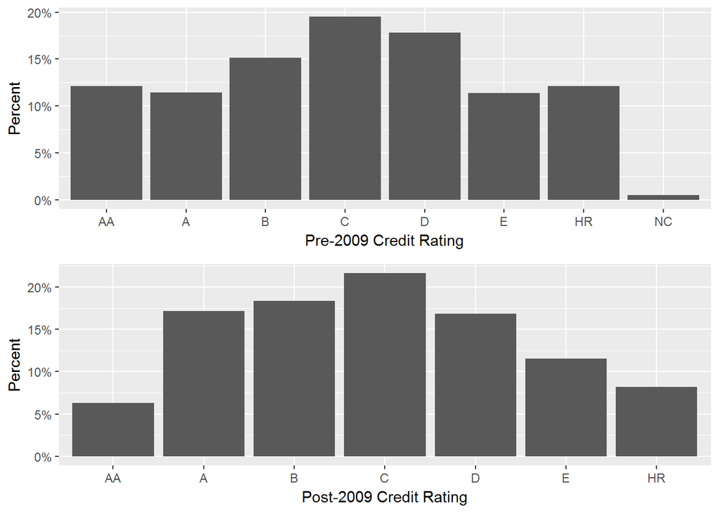

As can be seen from the plots, post 2009, the quality of the loans has clearly improved with a shift towards the left end of the credit rating scale (left being higher credit rating)

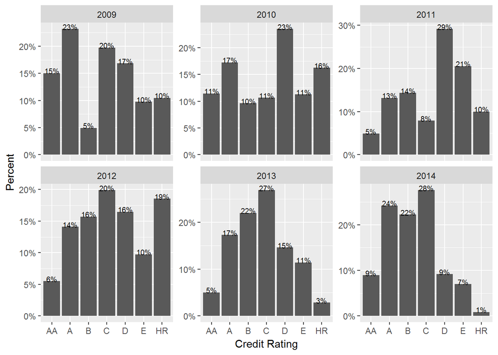

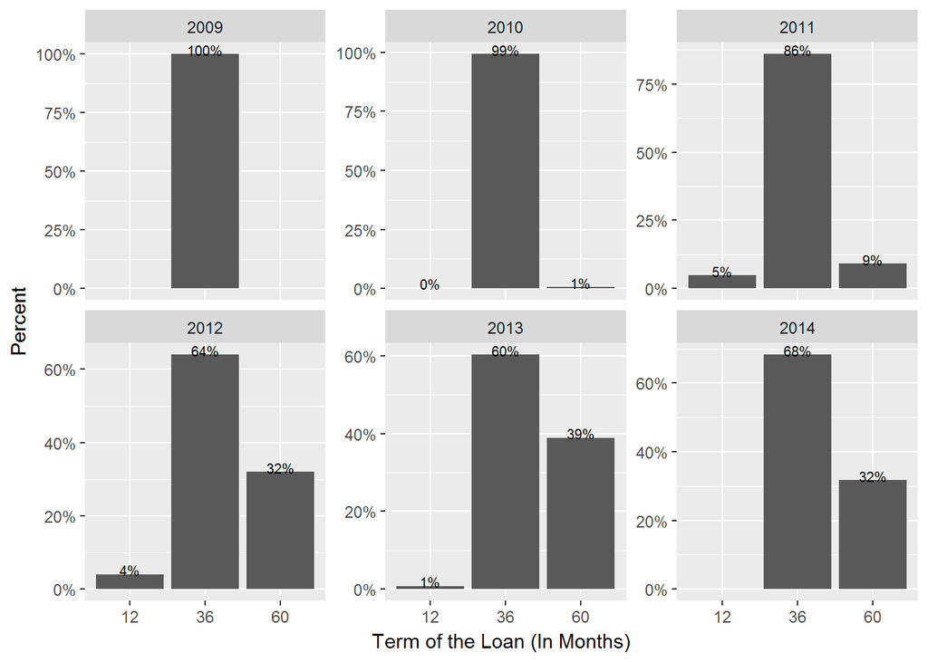

The plots indicate that overall, Credit ratings have shifted from a skewed distribution towards a normal distribution, with a large concentration of loans in the middle range of credit ratings

We next examine a few key characteristics of the loans:

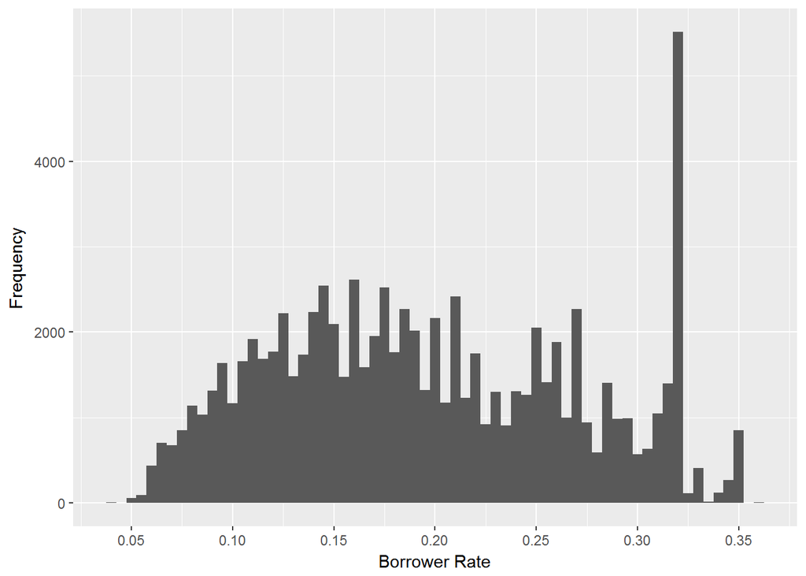

As can be seen from the histogram, the distribution of frequencies is skewed with a large number of loans with very high borrowing rates. Further study needs to be conducated to analyze how borrower rates are decided

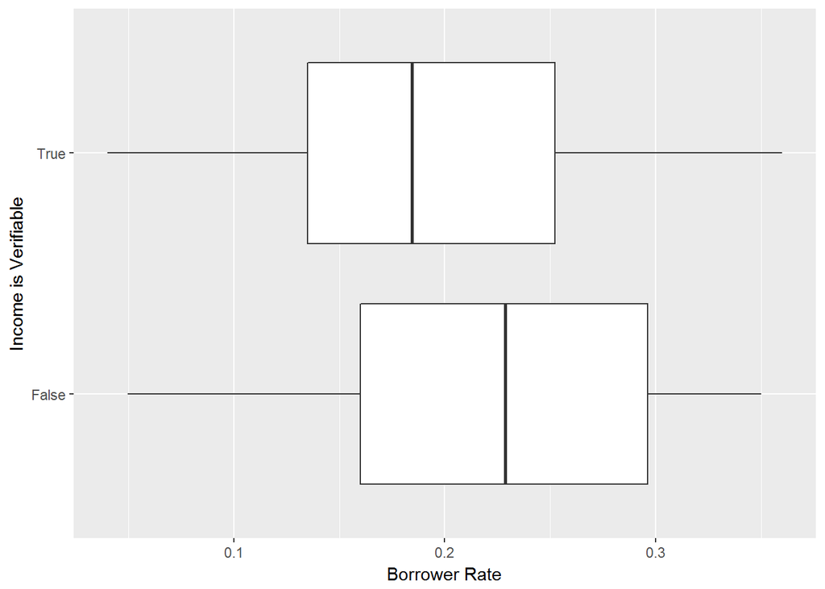

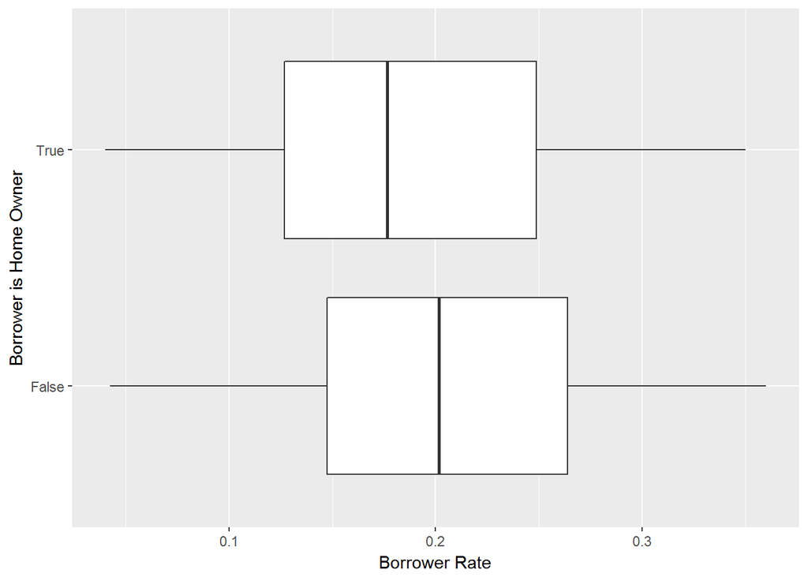

As can be seen from the box-plots above:

- A verifiable income results in a lower borrowing rate on average. This is because, lenders are more assured as to whether a given borrower can make the monthly payments and therefore, can factor that information into deciding the interest rate
- Home owners also typically have lower rates. This is because:
  - Ownership of a home could indicate that borrowers are capable of taking on a financial burden responsibly
  - The home can be used explicitly/implicitly as collateral for a loan and thus lower the rate

We now throw some light on borrower characteristics and loan characteristics that can faciliate further analysis

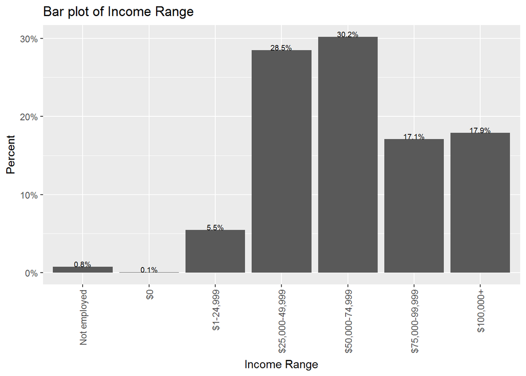

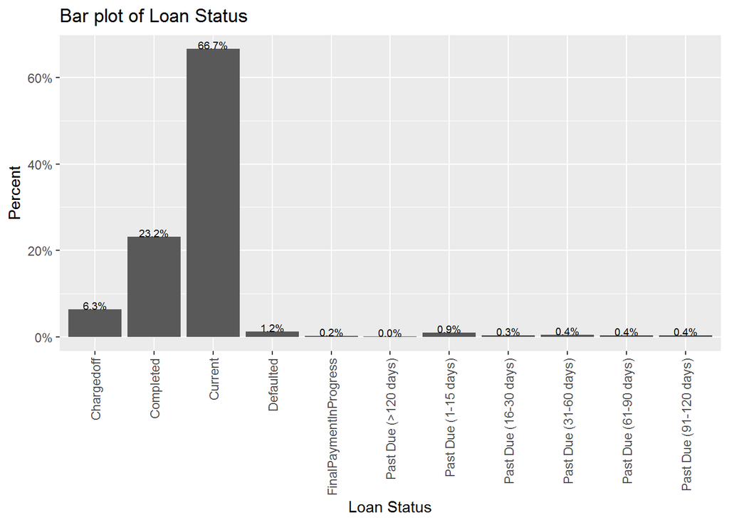

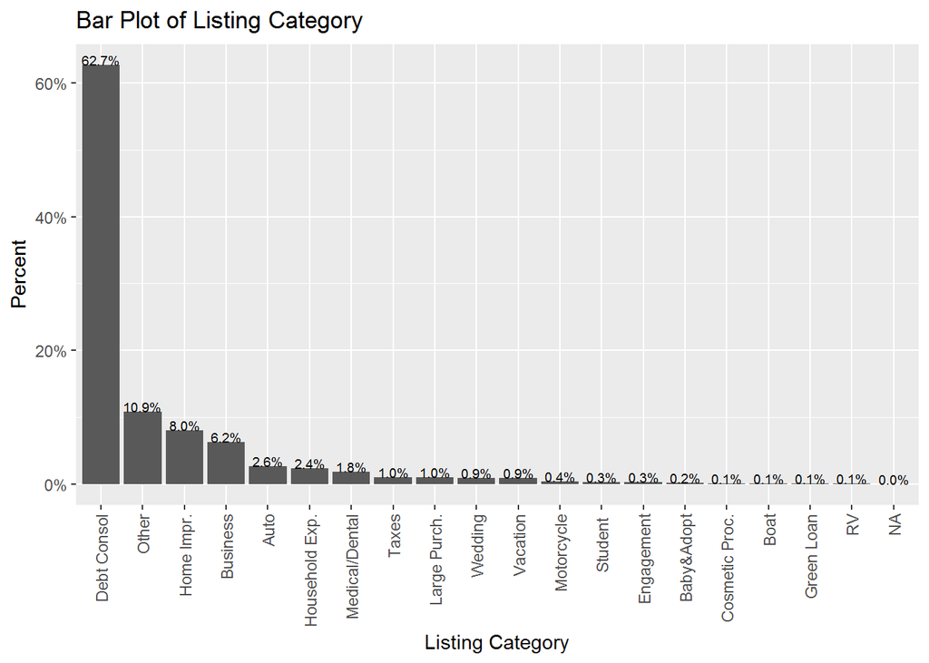

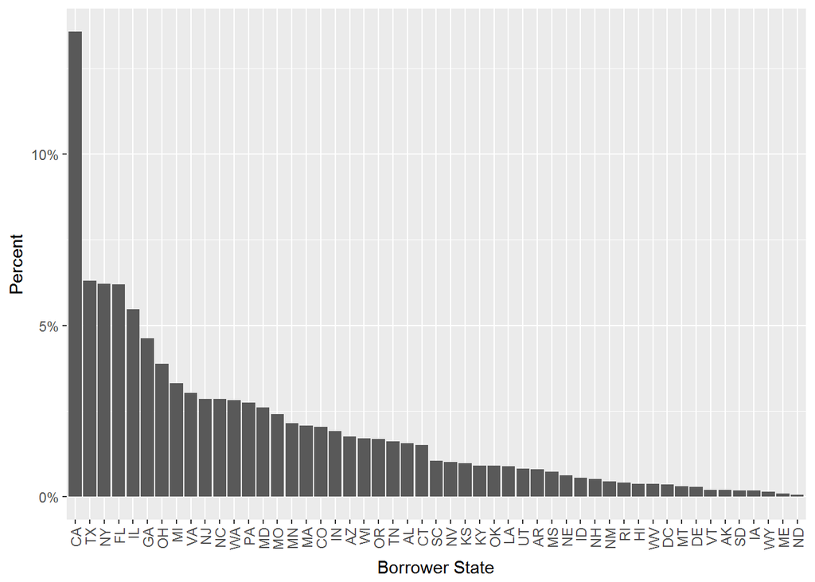

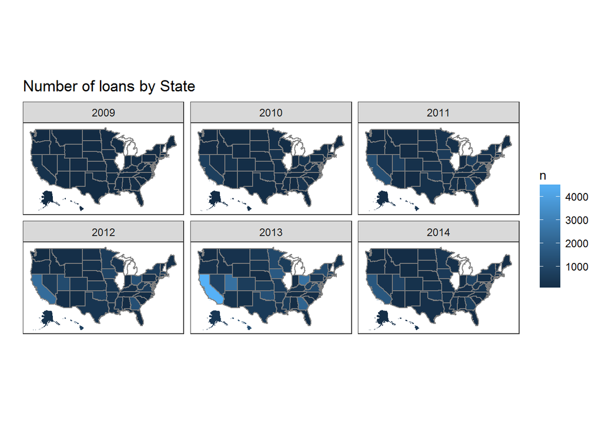

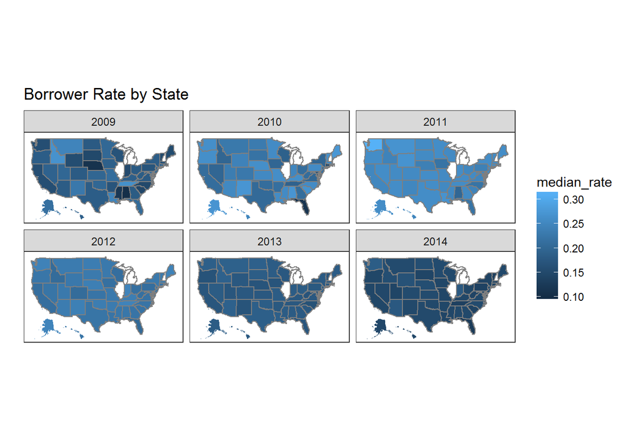

The second plot shows the median borrower rate by state across the years. One very interesting trend is that the borrower rates shot up between 2009 and 2011 across the country. They gradually improve over the years. Washington appears to be the state worst hit. These changes could be due to the fallout of the global financial crisis.

What is intriguing is that this was a period when interest rates were being lowered by the Federal Reserve

# Bivariate Plots Section

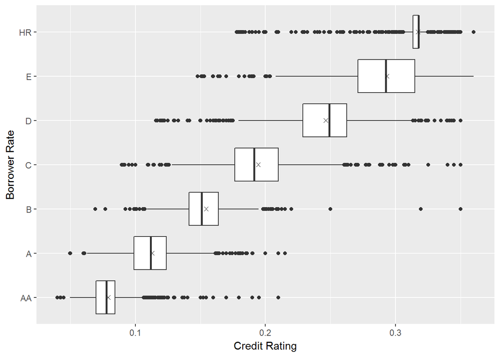

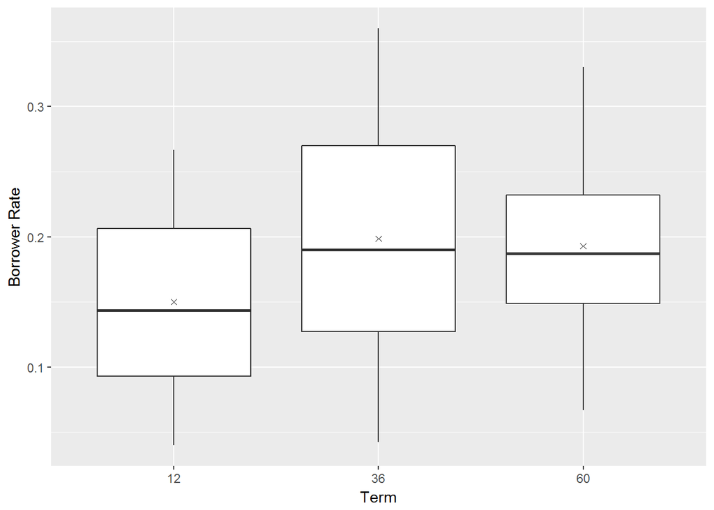

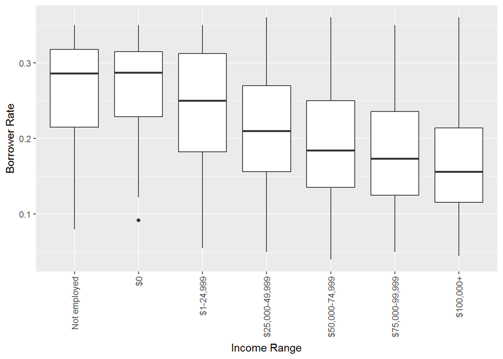

Setting aside the outliers, it is very apparent from the box-plot of Borrower Rate versus Credit Rating that a lower credit rate results in a higher cost of borrowing. This is because of the higher risk of default associated with a poorer credit rating.

The mean borrowing rate for each credit rating is typically to the right of the median credit rating, indicating a few outliers with very high borrowing rate. This proves that Credit Rating alone cannot determine the borrower rate. There is something more involved.

The borrowing rate is typically higher for longer term loans. This can be seen in the difference in rates between 12 month and 36 month loans, but not so much between the 36 month and 60 month loans.

The median borrowing rate is lower, the higher the income bracket of the borrower. This is probably because, the higher the income, the more likely the borrower will pay back the loan and hence the lower the risk of default, resulting in a reduction in the interest rate

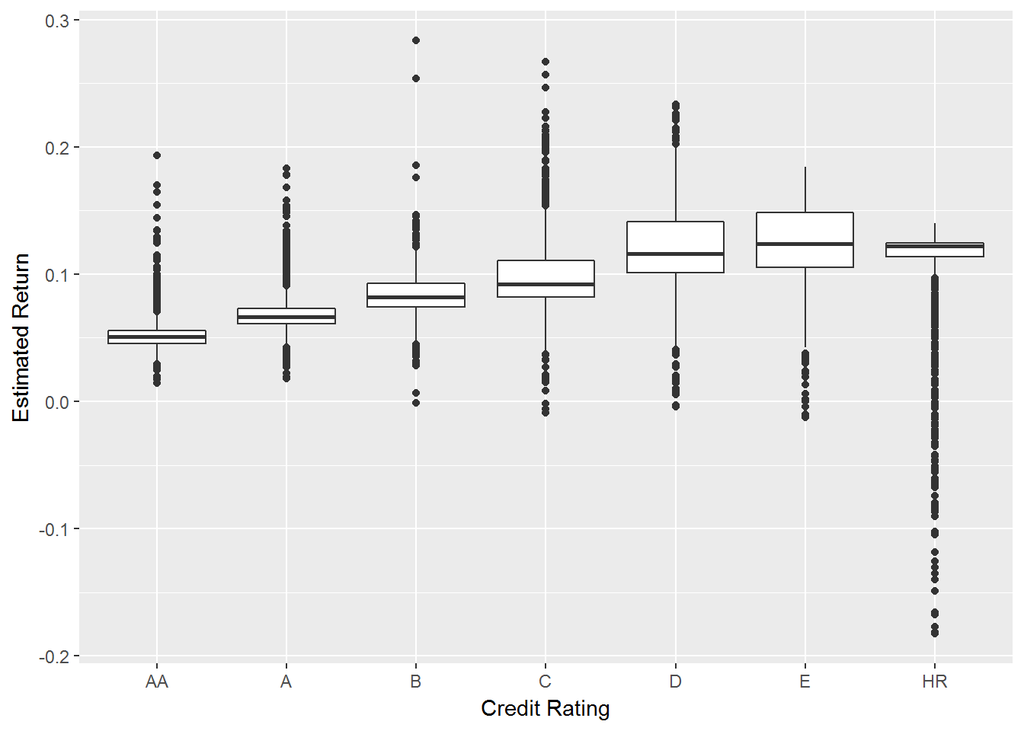

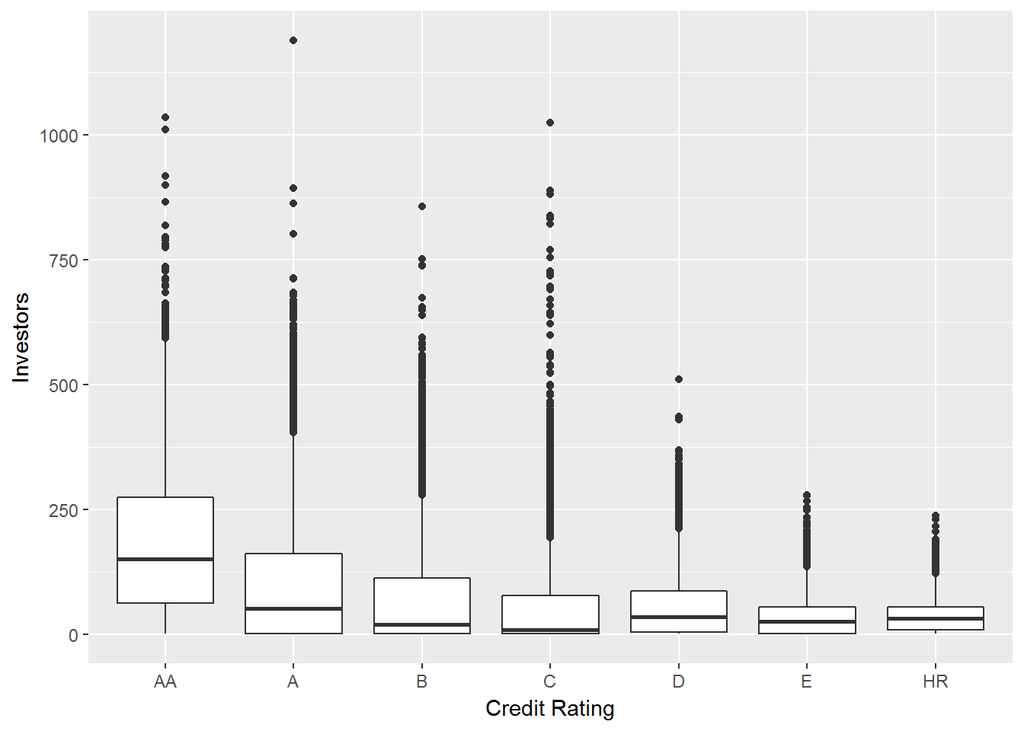

Credit Rating influences returns. In general, a higher risk should be associated with a higher return in order to compensate investors for the risk.

The first box plot shows this trend clearly, with lower rated loans attracting higher returns

The second box plot shows how this trend effects investor behaviour.

- As can be seen from the plot, investors in the AA-C range appear to be risk averse with fewer investors on average investing in lower rated loans
- However, the trend is reversed at very low credit ratings as risk seeking speculators actively invest in the loans

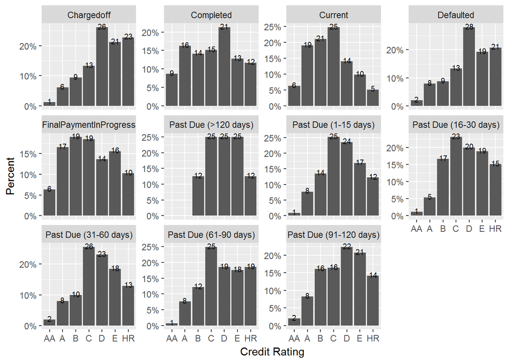

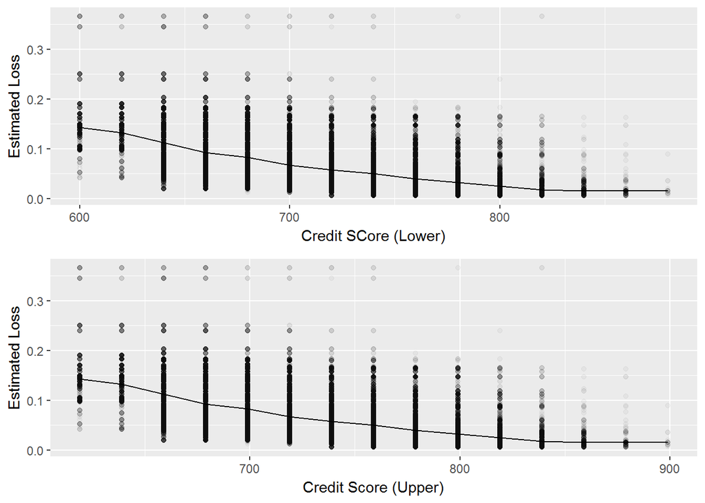

As can be seen from the graph, the higher rated loans are doing reasonably well with little delays or charge offs. However, the lower rated loans appear to be having problems.

- 25% of those loan payments are due for over 4 months
- 20% loan payments are due for over 3 months
- 20% loan payments are due for over 2 months

Estimated Loss versus Credit Score shows a clear trend. With a higher credit score, risk of default is lower and thefore, estimated loss is lower.

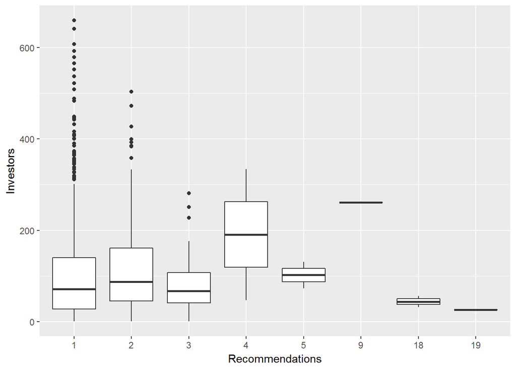

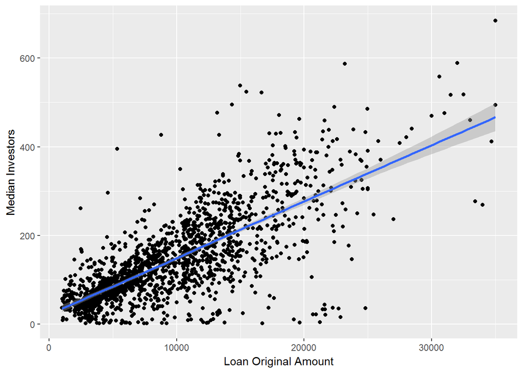

The first plot shows the relationship between number of investors in the loan and number of recommendations received by the borrower. While one would expect that more recommendations would imply that the borrower is trustworthy and invite more investors, the data doesn’t indicate that to be the case

The second plot shows the relationship between loan size and the median number of investors in that loan. One interesting trend here is that, the number of investors increases approximately linearly with the size of the loan. It is to be noted that the data has been modified to exclude loans with only one investor

# Multivariate Plots Section

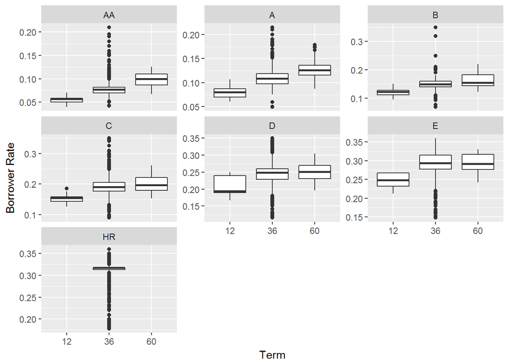

The above plot incorporates the credit rating, term and borrower rate and provides an interesting insight into the data. As expected, a higher credit rating attracts a lower interest rate and a longer term attracts a higher interest rate. However, the effect of term length on interest rate is reduced as credit rating is lowered. For example, the impact of a longer term on interest rate is not as prominent in D and E graded loans.

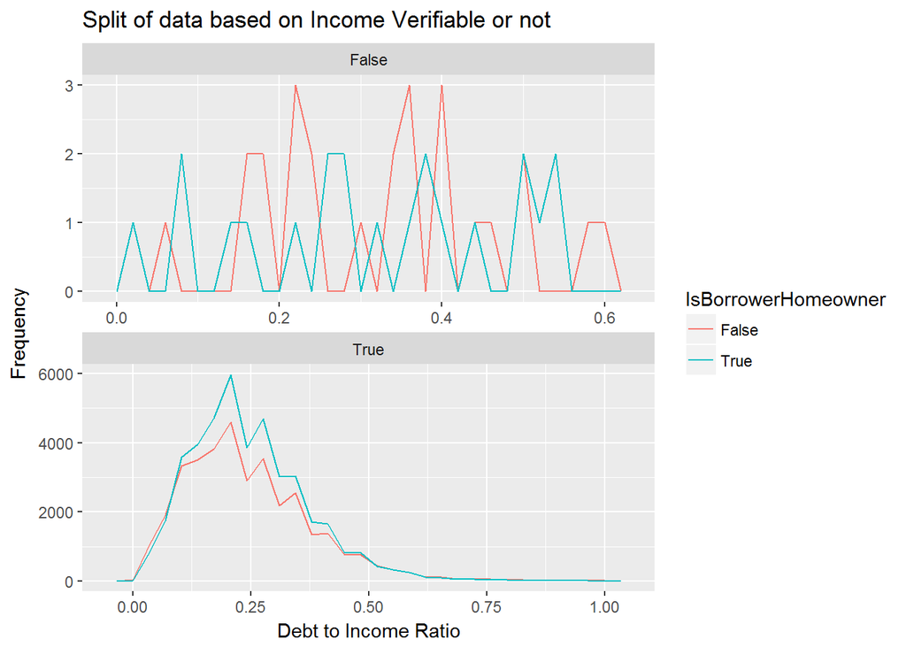

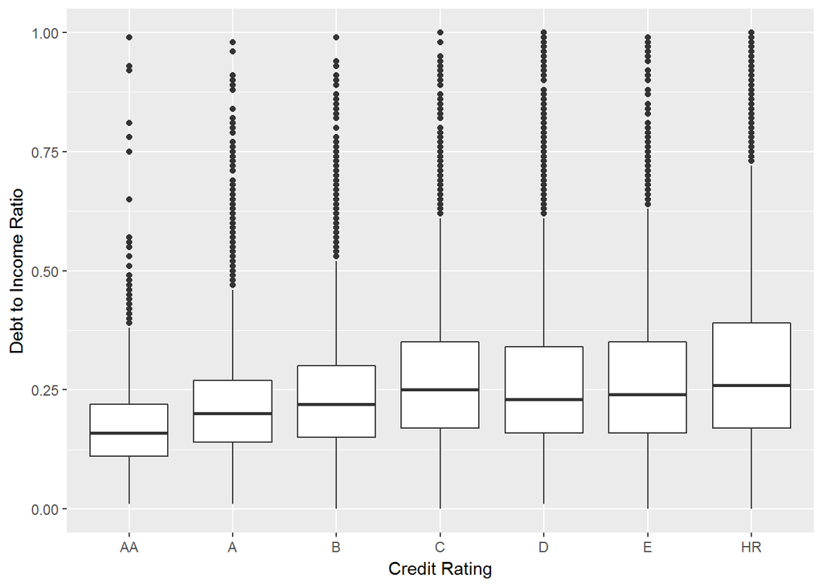

The data has been restricted to debt to income ratios less than 1 because the datapoints are above are few and widely dispersed, thereby distorting the study

From the first plot, we can see that Borrowers whose income cannot be verified are not permitted to take on debt exceeding ~0.6 of their stated Income.

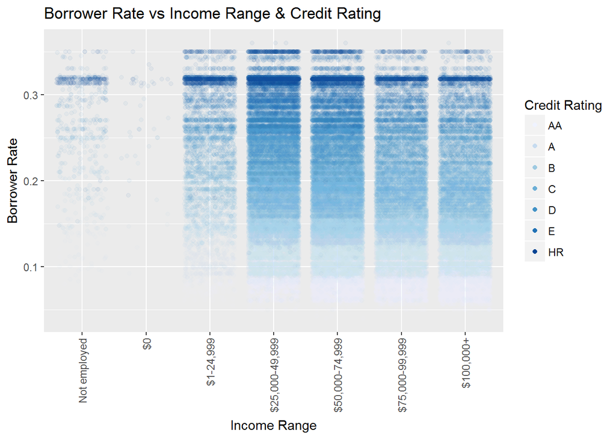

Firstly, jitter has been used because, the income levels are discrete categories and for each income level, we would get a series of points lined up vertically making visualization difficult.

Secondly, alpha = 1/20 has been used because there is clear overplotting due to several loans having the same or very close borrowing rates

As can be seen from the plot, income does not seem to be as important a factor for determining borrower rate as credit rating is. There is a range of credit ratings at all levels of income including the highest of $100,000+. However, there are distinct bands of borrowing rates for each credit rating.

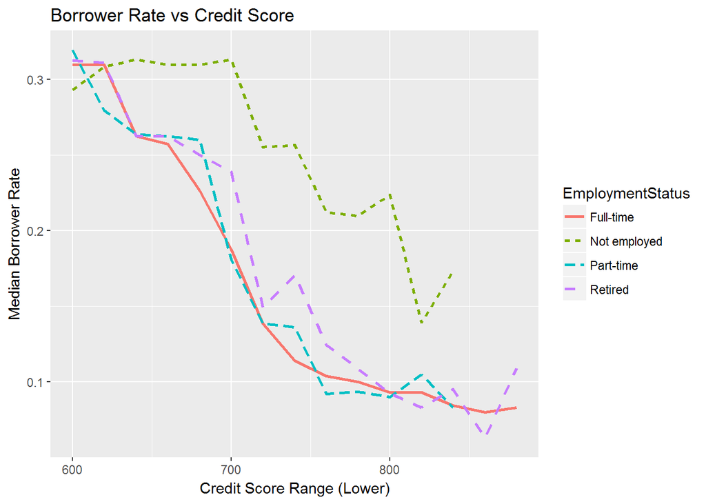

From the plot of median borrower rate versus credit score, we can observe a clear trend. On the one hand, an increase in credit score lowers the borrowing rate for the loan. On the other other hand, borrowing rate varies by employment status as well. While full-time employees get the best rates, the rate gradually goes up as we move towards part-time, retired and unemployed.

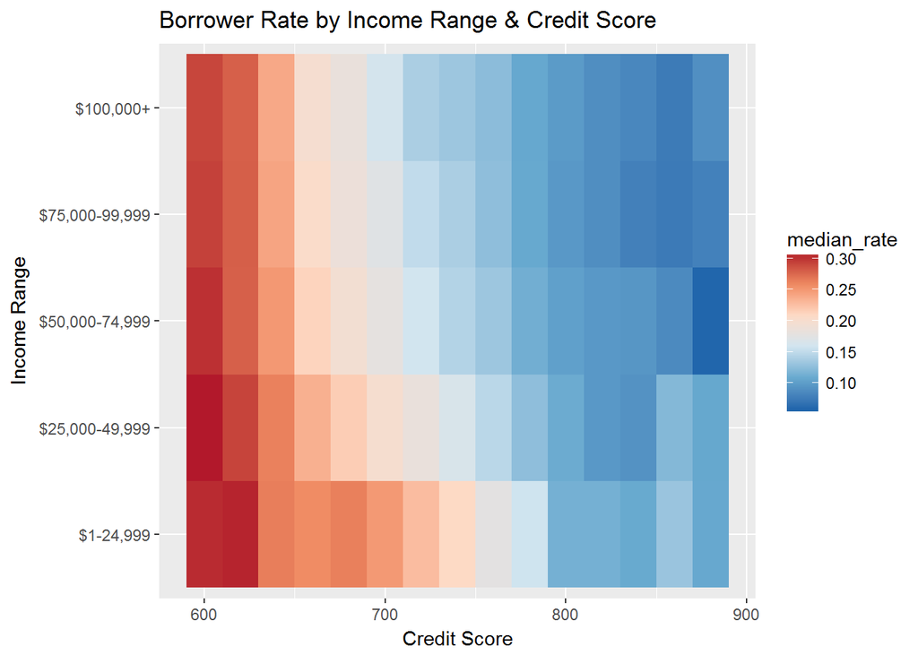

The level plot shows an interesting trend. The median borrower rate is effected by both Income Range & Credit Score as evident in the earlier plots. For a lower credit score, we would expect the borrowing rate to be higher. However, in case the income levels are higher, that compensates for poor credit score to some extent, thereby lowering the borrowing rate.

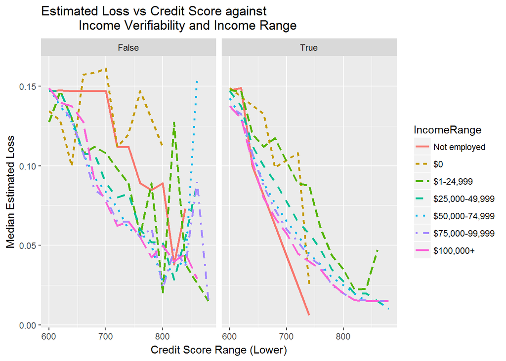

The plot of median estimated loss vs credit score shows an interesting trend. In the absence of a verifiable source of income, there is no discernible pattern in the data. However, in case there is a verifiable source of income, for a credit score greater than 650, there is a very clear trend in the data. Higher credit score implies lower estimated loss. Furthermore, higher income also implies lower estimated loss.

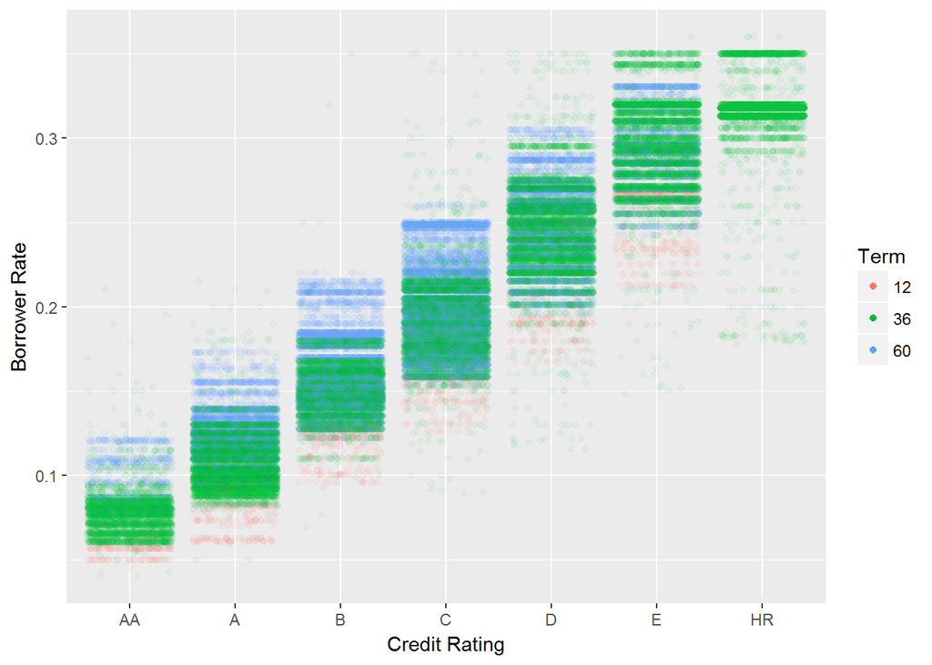

Firstly, jitter has been applied because the credit ratings are categorical variables and jitter can help make the effect more visually apparent

Secondly, alpha = 1/20 has been applied becuase there is a large amount of overplotting resulting from several loans with same credit rating having the same or very close borrower rates.

Two things are very clear from the plot:

- There are distinct bands for each term length for any given credit rating indicating that longer term is typically associated with higher interest rates
- The bands begin to overlap as the credit rating falls, indicating that at lower ratings additional factors are taken into account before assigning rating

# Final Plots and Summary

### Plot One

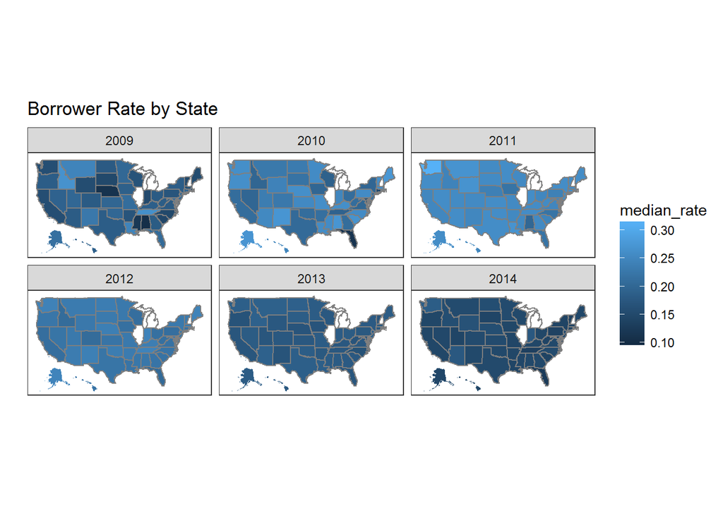

### Description One

This plot shows the wide variation in borrower rates both across space and across time. Some states have significantly higher rates than others and rates across the country increased between 2009 and 2011. This graph suggests that further exploration of what variables effect interest rates is important.

### Plot Two

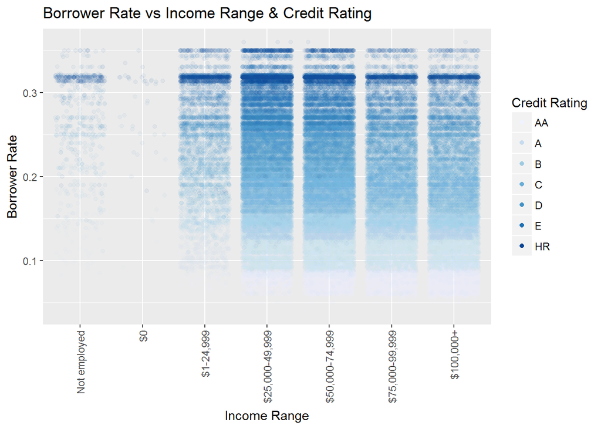

### Description Two

This plot shows the relative importance of credit rating and income levels in determining the interest rate charged to borrowers.

- From the plot, it is very clear that credit rating is a much more important factor than income levels
- Even at very high income levels, there is a spread of credit ratings corresponding a spread of borrower rates
- The effect of credit rating is very clear, with there being distinct bands of rates depending on credit rating
- As credit ratings worsen, the bands of interest rates begin to increasingly overlap, indicating that additional factors are responsible in determining rates

### Plot Three

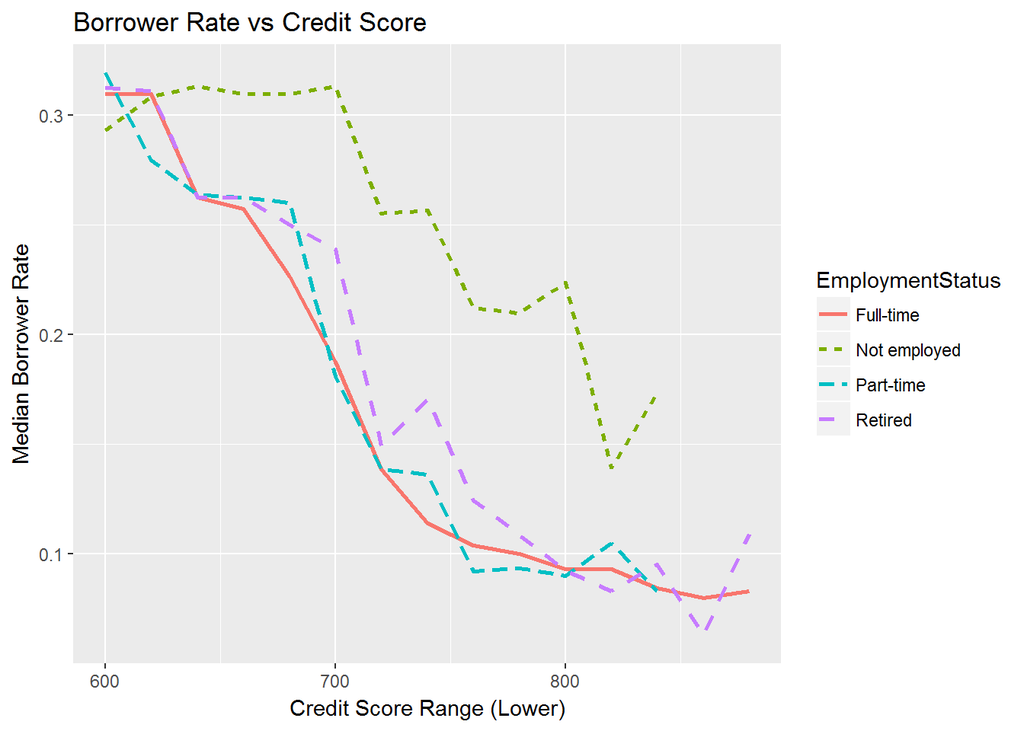

### Description Three

This graph shows the effect of two other variables that effect borrower rates. While the credit rating is a loan characteristic, credit scores are borrower characteristics.

- With increasing credit scores, the median borrower rate gets lowered indicating that credit scores are an important factor in determining interest rates
- Employment status is another very important factor - Full-time employees get better rates than part-time employees, who get better rates than retirees and unemployed individuals

# Reflection

- The data analysis exercise revealed some interesting insights into the variables that effect the borrower rates.
  - These variables include Credit Rating, Credit Scores, Income Range, Employment Status, Term of the loan and Home Ownership
- The biggest challenge was the large number of variables in itself
  - Choosing which variables to explore and studying the interactions was a challenge
  - Some of the variables could be related to a third variable by virtue of their relationship with each other. Identifying and separating such relationships is a challenge which needs more information on related variables
- Some very interesting and unexpected observations were made in this analysis:
  - Over 60% of the loans were for debt consolidation, indicating that the rates on P2P lending were much more favorable
  - Interest rates across the country were rising between 2009-11 indicating a potential concern about credit worthiness of borrowers. However, it was surprising that this was a time when the Federal Reserve lowered interest rates
  - Another interesting factor observed was that, while the income levels were less important than credit scores/credit ratings in determining borrower rates, a higher income level compensated somewhat for a poor credit score and could fetch a better rate.

### Scope for future work

There is plenty of scope for future work based on this dataset: